# Distribuciones Discretas I

Edimer David Jaramillo

2 de mayo de 2018

# Distribución Bernoulli

En determinados experimentos suele ocurrir que existan sólo dos resultados posibles:

- Presencia o ausencia
- Sí o no
- Defectuoso o no defectuoso
- Ganó o perdió
- Hembra o macho

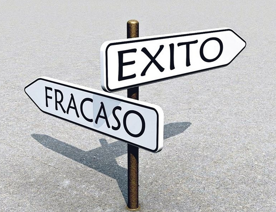

- Probabilidad de éxito ($p$)
- Probabilidd del fracaso ($q = 1 - p$)
- $p + q = 1$

Una variable aleatoria X tiene distribución Bernoulli si su función de densidad (f.m.p.) es:
$$f(x)=p^xq^{1-x}, x=0,1$$

Note que:

- $P(x=0)=f(0)=p^0q^{1-0}=q$
- $P(x=1)=f(1)=p^1q^{1-1}=p$

Notación:
$$X \sim Bernoulli(p)$$

## Esperanza ($E[X]$) y varianza ($Var[X]$)

- **Esperanza matemática:**

$$E[X]=1\ \times p\ + 0\ \times (1-p) = p$$
$$E[X^2]=1^2\ \times p\ + 0^2\ \times (1-p) = p$$

- **Varianza:**

$$Var[X]=E[X^2]-[E(x)]^2=p\ - p^2 = p \times (1-p)=p \times q$$

# Distribución Binomial

Ocurre cuando se cumple lo siguiente:

- Se realizan o repiten $n$ ensayos Bernoulli
- El parámetro $p$ se mantiene constante entre ensayos
- Los ensayos son independientes entre sí

**Objetivo:** el problema de interés radica en el número de “éxitos” en $n$ casos estudiados (el éxito no necesariamente implica que sea bueno, sólo determina la ocurrencia del evento).

Una variable aleatoria $X$ tiene distibución Binomial si su función de densidad (f.m.p.) es:
$$f(x)=\binom{n}{x}p^x(1-p)^{n-x}; con x = 0, 1, 2, ..., n$$
Notación:
$$X \sim B(n, p)$$
Donde:

- $n$: número de ensayos
- $p$: probabilidad de éxito

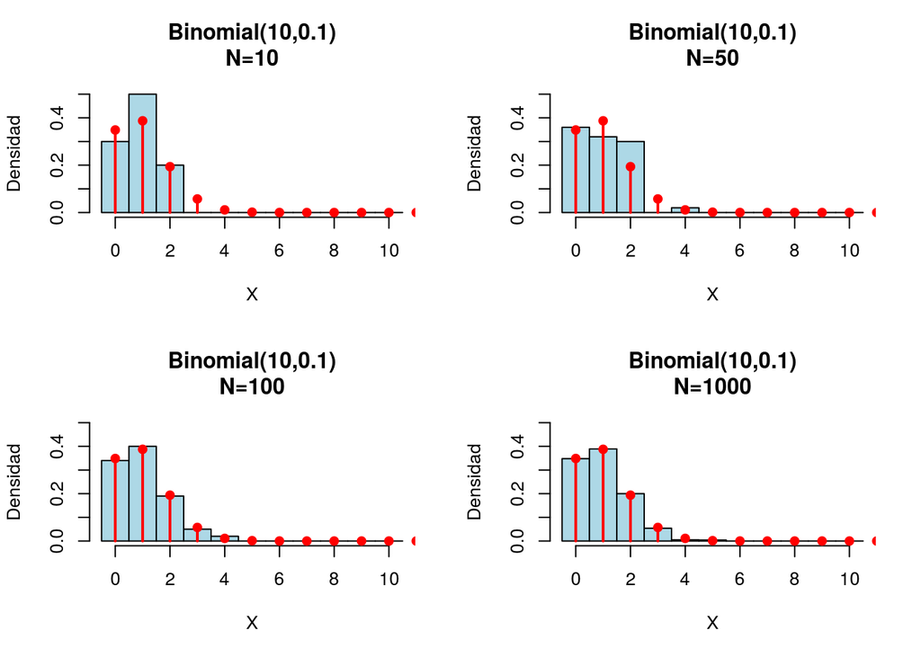

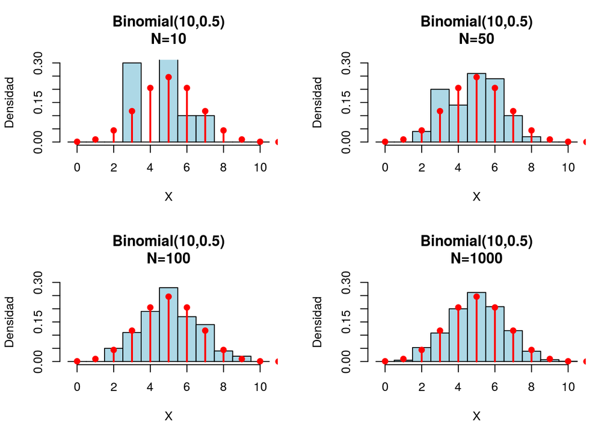

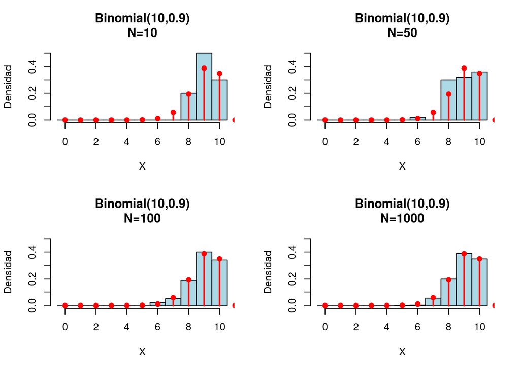

[Código en R de gráficas de distribuciones](https://rpubs.com/cdsantae/Distribuciones)

## Esperanza ($E[X]$) y varianza ($Var[X]$)

- $E[X]=n \times p$
- $Var[X]=n \times p \times q = n \times p \times (1-p)$

## Ejemplos

**Ejemplo 1:**

- Suponga que se toman 10 semillas de un tipo de pasto y se registran los eventos “germinó” o “no germinó” después de cinco días de la siembra. Las semillas están lo suficientemente aisladas como para garantizar respuestas independientes. Si la probabilidad de la germinación es $0.25$ (cada semilla), obtener:
  1. Probabilidad de que germinen 7 de las 10 semillas
  2. Probabilidad de que germinen al menos 3 de las 10 semillas
  3. Probabilidad de que germinen máximo 5 semillas
  4. La esperanza de esta variable aleatoria
  5. La varianza

**Solución:**
$$X \sim B(10; 0.25)$$

1. $P(X = 7) = \binom{10}{7}0.25^7(1-0.25)^{10 - 7}=0.0031$
2. $P(X \geq 3)= P(X=3) + P(X=4) + P(X=5) + ..., Ṕ(X=10) \\ = 1 - P(X=0) + P(X=1) + P(X=2) = 0.4744$
3. $P(X \leq 5) = P(X=0) + P(X=1) + ... + P(X=5) \\ = 0.0563 + 0.1877 + 0.2816 + 0.2503 + 0.1460 + 0.0584 = 0.9803$
4. $E[X] = n \times p = 10 \times 0.25 = 2.5$
5. $Var[X] = n \times p \times 1 = 10 \times 0.25 \times (1-0.25) = 1.875$

**Solución con R:**

Funciones importantes:

- `rbinom()`: generar números bajo la distribución Binomial
- `dbinom()`: función masa de probabilidad
- `pbinom()`: función de distribución acumulada

```r
dbinom(x = 7, size = 10, prob = 0.25) # P(X=7)
```

```
## [1] 0.003089905
```

```r
1-sum(dbinom(0:2, 10, 0.25)) #P(X >= 3)
```

```
## [1] 0.4744072
```

```r
1-pbinom(2, size = 10, prob = 0.25) #P(X >= 3)
```

```
## [1] 0.4744072
```

```r
pbinom(5, 10, 0.25) #P(X <= 5)
```

```
## [1] 0.9802723
```

```r
(media <- 10 * 0.25)
```

```
## [1] 2.5
```

```r
(Varianza <- 10 * 0.25 * (1 - 0.25))
```

```
## [1] 1.875
```

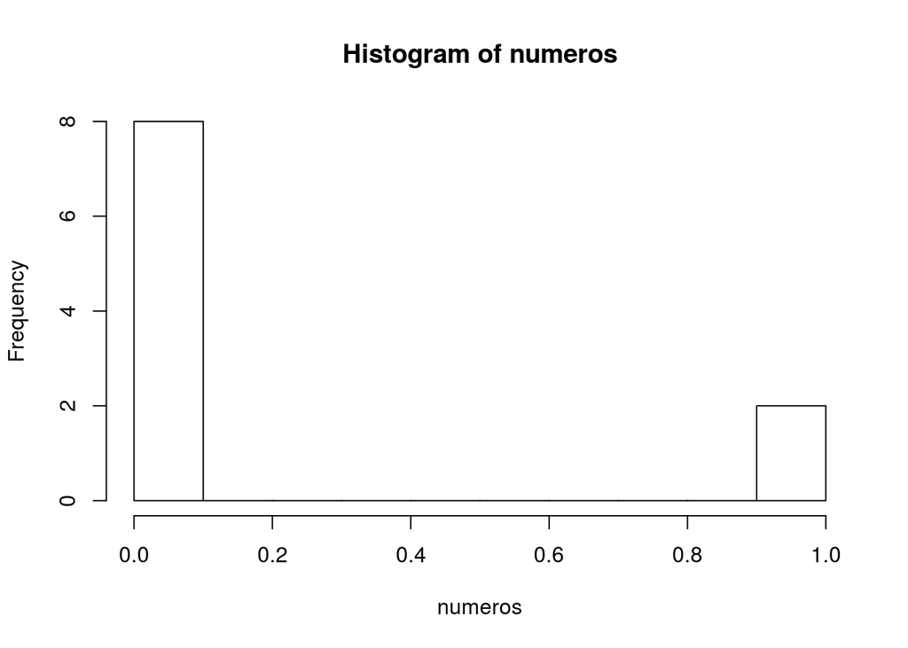

```r
numeros <- rbinom(10, 1, 0.25)
hist(numeros, breaks = 10)
```

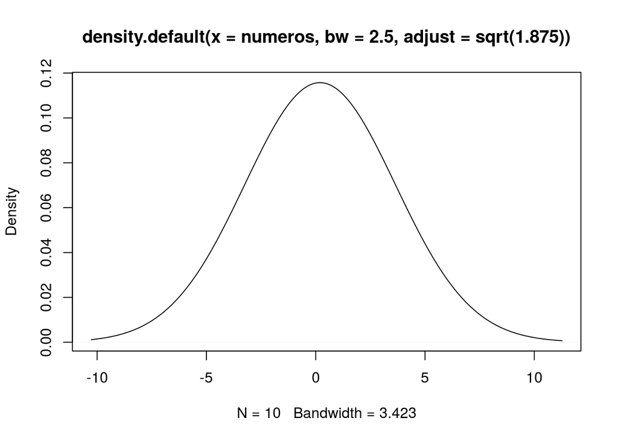

```r
plot(density(numeros, 2.5, sqrt(1.875)))
```

**Ejemplo 2:**

- Suponga que la probabilidad de tener una unidad defectuosa en una línea de ensamble es de $0.05$. Obtener:
  1. La probabilidad de que en 20 unidades seleccionadas al azar, dos sean defectuosas.
  2. La probabilidad de que máximo dos de las 20 unidades estén defectuosos.
  3. La probabilidad de que mínimo dos unidades de las 20, estén defectuosas.

**Solución:**

```r
dbinom(x = 2, size = 20, prob = 0.05) #P(X = 2)
```

```
## [1] 0.1886768
```

```r
sum(dbinom(0:2, 20, 0.05)) #P(X <= 2)
```

```
## [1] 0.9245163
```

```r
pbinom(2, 20, 0.05) #P(X <= 2)
```

```
## [1] 0.9245163
```

```r
sum(dbinom(2:20, 20, 0.05)) #P(X >= 2)
```

```
## [1] 0.2641605
```

```r
1-pbinom(1, 20, 0.05) #P(X >= 2)
```

```
## [1] 0.2641605
```

**Ejemplo 3:**

- Un examen de opción múltiple contiene 10 preguntas. Cada pregunta tiene cuatro opciones, de las cuales sólo una es la correcta. El examen se aprueba si se responden correctamente mínimo seis preguntas. Si el estudiante “adivina” las preguntas, obtener:
  1. La probabilidad de aprobar el examen
  2. La probabilidad de responder correctamente a 6 preguntas
  3. Halle la esperanza matemática
  4. Halle la varianza

**Solución:**

```r
#Probabilidad de ganar el examen es igual a P(X >= 6)
sum(dbinom(6:10, 10, 0.25))
```

```
## [1] 0.01972771
```

```r
1-pbinom(5, 10, 0.25)
```

```
## [1] 0.01972771
```

```r
#Probabilidad de responder correctamente 6 preguntas
dbinom(6, 10, 0.25)
```

```
## [1] 0.016222
```

```r
#Esperanza
(media_ej3 <- 10 * 0.25)
```

```
## [1] 2.5
```

```r
(var_ej3 <- 10 * 0.25 * (1 - 0.25))
```

```
## [1] 1.875
```

```r
(desviacion <- sqrt(var_ej3))
```

```
## [1] 1.369306
```

# Distribución Poisson

La distribución de Poisson da un modelo para el número de eventos (conteos) por intervalo.

- Número de huevos de un insecto en una oviposición
- Número de bacterias en una muestra de agua
- Número de insectos por $m^2$
- Número de clientes por hora
- Llamadas por hora

Una variable aleatoria $X$ tiene distribución Poisson si su función de densidad es:
$$f(x)=\frac{e^{-\lambda} \lambda^x}{x!}; x = 0, 1, 2, ...$$
Notación:
$$X \sim Poisson(\lambda)$$

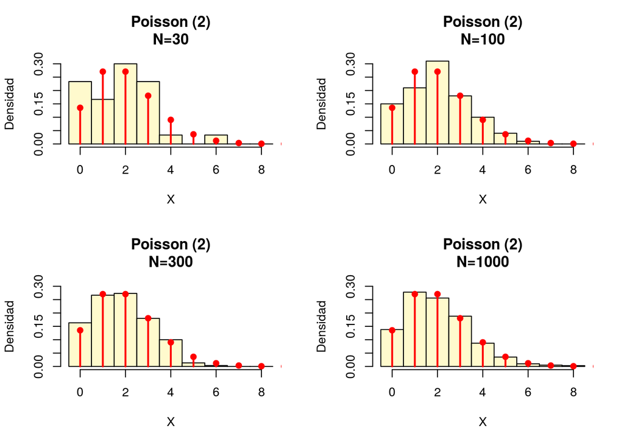

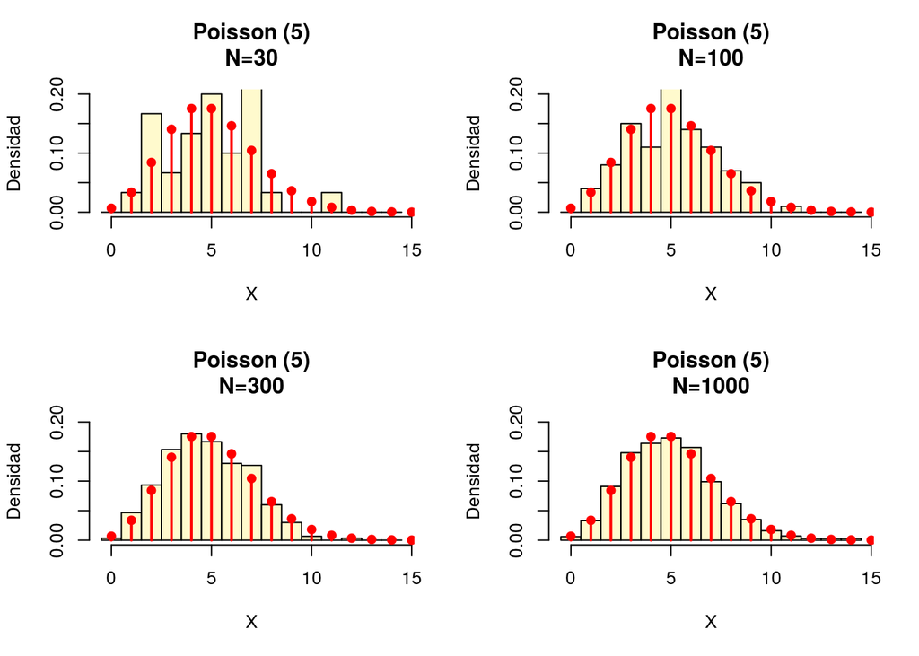

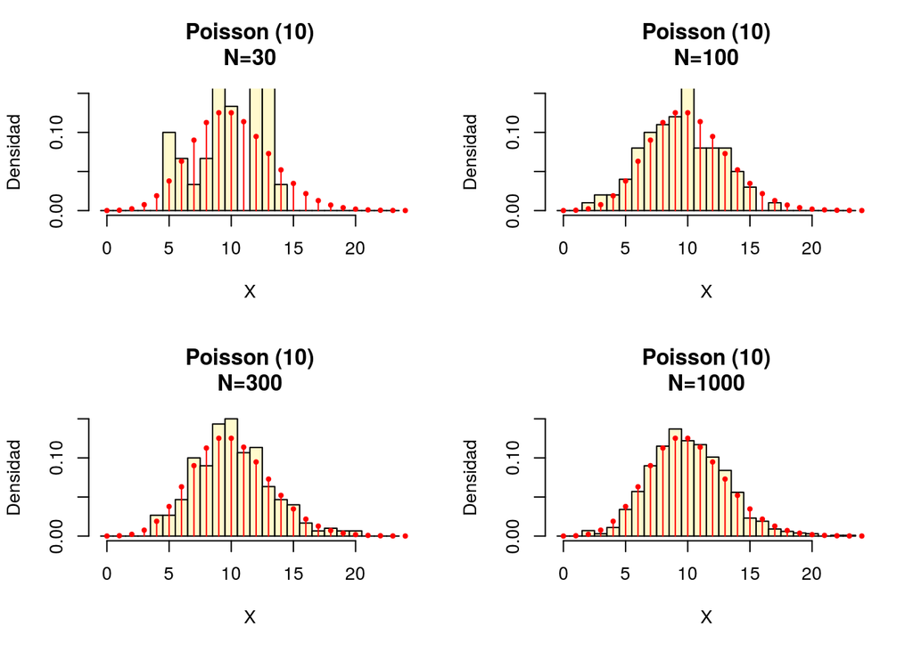

## Esperanza ($E[X]$) y varianza ($Var[X]$)

- $E[X]= \lambda$
- $Var[X]= \lambda$

## Ejemplos

**Ejemplo 1:**

- Si el número promedio de picaduras de una plaga cualquiera por semilla es $0.2$ (es decir, que en promedio, de cada 100 semillas, 20 tienen picadura). Obtener:
  1. ¿Cuántas de 100 semillas no tendrán picadura?
  2. ¿Cuántas tendrán una sola picadura?
  3. ¿Cuántas tendrán más de 1 picadura?

**Solución:**

- $P(X=0) = \frac{0.2^0e^{-0.2}}{0!} = 0.819$
- $P(X=1) = \frac{0.2^1e^{-0.2}}{1!} = 0.164$
- $p(X > 1) = 1 - P(X=0) + P(X=1) = 1 - 0.982 = 0.018$

**Solución con R:**

Funciones importantes:

- `rpois()`: generar números bajo la distribución Poisson
- `dpois()`: función masa de probabilidad
- `ppois()`: función de distribución acumulada

```r
dpois(x = 0, lambda = 0.2) #P(X=0)
```

```
## [1] 0.8187308
```

```r
dpois(x = 1, lambda = 0.2) #P(X=1)
```

```
## [1] 0.1637462
```

```r
1-sum(dpois(x = 0:1, lambda = 0.2)) #P(X > 1)
```

```
## [1] 0.0175231
```

```r
1-ppois(1, 0.2) #P(X > 1)
```

```
## [1] 0.0175231
```

```r
num_pois <- rpois(n = 100, lambda = 0.2)
table(num_pois)
```

```
## num_pois
##  0  1  2
## 82 17  1
```

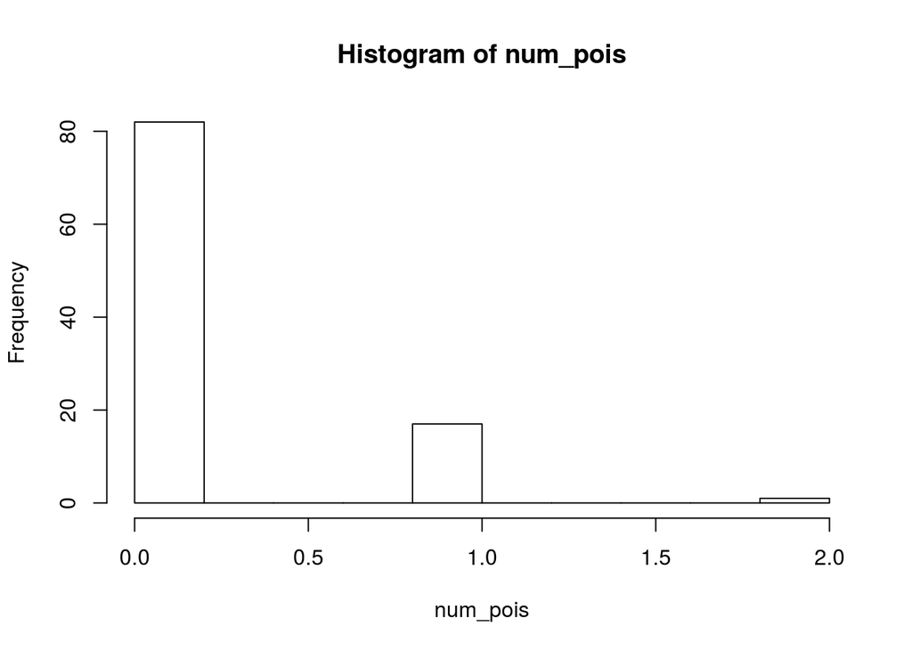

```r
hist(num_pois)
```

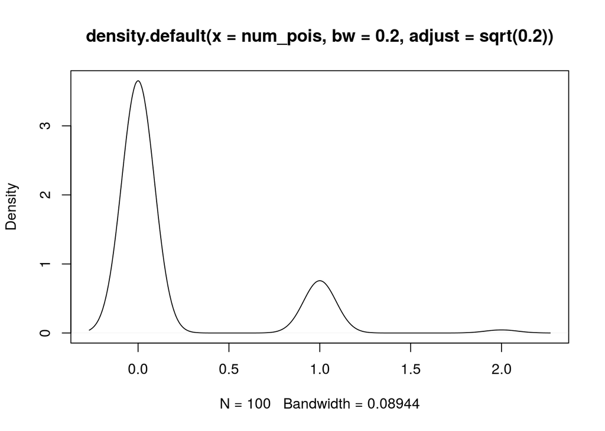

```r
plot(density(num_pois, 0.2, sqrt(0.2)))
```

**Ejemplo 2:**

- Supongamos que el número de imperfecciones en un alambre delgado de cobre sigue una distribución Poisson con una media de 2.3 ($\lambda$) imperfecciones por milímetro. Obtener:
  1. La probabilidad de 2 imperfecciones en un milímetro de alambre.
  2. la probabilidad de 10 imperfecciones en 5 milímetros de alambre.
  3. La probabilidad de al menos una imperfección en 2mm de alambre.

**Solución:**

```r
 #P(X = 2)
dpois(x = 2, lambda = 2.3)
```

```
## [1] 0.2651846
```

```r
#P(X = 10)
#Para 1 mílimetro lambda = 2.3, para 5 mm = (2.3 * 5) = 11.5
dpois(x = 10, lambda = 11.5)
```

```
## [1] 0.1129351
```

```r
#P(X >= 1)
#Para 1 mílimetro lambda = 2.3, para 2 mm = (2.3 * 2) = 4.6
1-sum(dpois(x = 0, lambda = 4.6))
```

```
## [1] 0.9899482
```

```r
1-ppois(0, 4.6)
```

```
## [1] 0.9899482
```